# COMPSCIX 415.2 Homework 7

Sanatan Das

March 17, 2018

# Code and Documents Git Repository

All the work can be found in the below Git repository location:

https://github.com/sanatanonline/compscix-415-2-assignments

# Load packages (prerequisites to run the code in this document)

```r
library(tidyverse)
library(broom)
```

# Analysis of Ames Housing dataset and predicting the price

## Load the data

**Exercise 1**

**Load the train.csv dataset into R. How many observations and columns are there?**

**Answer**

```r
# Read from train.csv file
train <- read_csv("C:/view/opt/apps/git/R/compscix-415-2-assignments/train.csv")
# glimpse train
glimpse(train)
```

```
## Observations: 1,460
## Variables: 81
## $ Id            <int> 1, 2, 3, 4, 5, 6, 7, 8, 9, 10, 11, 12, 13, 14, 1...
## $ MSSubClass    <int> 60, 20, 60, 70, 60, 50, 20, 60, 50, 190, 20, 60,...
## $ MSZoning      <chr> "RL", "RL", "RL", "RL", "RL", "RL", "RL", "RL", ...
## $ LotFrontage   <int> 65, 80, 68, 60, 84, 85, 75, NA, 51, 50, 70, 85, ...
## $ LotArea       <int> 8450, 9600, 11250, 9550, 14260, 14115, 10084, 10...
## $ Street        <chr> "Pave", "Pave", "Pave", "Pave", "Pave", "Pave", ...
## $ Alley         <chr> NA, NA, NA, NA, NA, NA, NA, NA, NA, NA, NA, NA, ...
## $ LotShape      <chr> "Reg", "Reg", "IR1", "IR1", "IR1", "IR1", "Reg",...
## $ LandContour   <chr> "Lvl", "Lvl", "Lvl", "Lvl", "Lvl", "Lvl", "Lvl",...
## $ Utilities     <chr> "AllPub", "AllPub", "AllPub", "AllPub", "AllPub"...
## $ LotConfig     <chr> "Inside", "FR2", "Inside", "Corner", "FR2", "Ins...
## $ LandSlope     <chr> "Gtl", "Gtl", "Gtl", "Gtl", "Gtl", "Gtl", "Gtl",...
## $ Neighborhood  <chr> "CollgCr", "Veenker", "CollgCr", "Crawfor", "NoR...
```

[output cut: 68 more lines]

So there are 1460 observations with 81 columns (variables)

## Split the Data to training set and test set

**Exercise 2**

**Normally at this point you would spend a few days on EDA, but for this homework we will get right to fitting some linear regression models.**

**Our first step is to randomly split the data into train and test datasets. We will use a 70/30 split. There is an R package that will do the split for you, but let’s get some more practice with R and do it ourselves by filling in the blanks in the code below.**

```r
# load packages
library(tidyverse)
library(broom)
# When taking a random sample, it is often useful to set a seed so that
# your work is reproducible. Setting a seed will guarantee that the same
# random sample will be generated every time, so long as you always set the
# same seed beforehand
set.seed(29283)
# This data already has an Id column which we can make use of.
# Let's create our training set using sample_frac. Fill in the blank.
train_set <- train %>% sample_frac(____)
# let's create our testing set using the Id column. Fill in the blanks.
test_set <- train %>% filter(!(____ %in% ____$Id))
```

**Answer**

Let’s fill in the blanks.

```r
# When taking a random sample, it is often useful to set a seed so that
# your work is reproducible. Setting a seed will guarantee that the same
# random sample will be generated every time, so long as you always set the
# same seed beforehand
set.seed(29283)
# This data already has an Id column which we can make use of.
# Let's create our training set using sample_frac. Fill in the blank.
train_set <- train %>% sample_frac(0.7)
# Print train set
train_set
```

```
## # A tibble: 1,022 x 81
##       Id MSSubClass MSZoning LotFrontage LotArea Street Alley LotShape
##    <int>      <int> <chr>          <int>   <int> <chr>  <chr> <chr>
##  1    22         45 RM                57    7449 Pave   Grvl  Reg
##  2   637         30 RM                51    6120 Pave   <NA>  Reg
##  3   121         80 RL                NA   21453 Pave   <NA>  IR1
##  4   575         80 RL                70   10500 Pave   <NA>  Reg
##  5  1423        120 RM                37    4435 Pave   <NA>  Reg
##  6  1169         70 RL               120   13728 Pave   <NA>  Reg
##  7  1261         60 RL                NA   24682 Pave   <NA>  IR3
##  8  1319         20 RL                NA   14781 Pave   <NA>  IR2
##  9   116        160 FV                34    3230 Pave   Pave  Reg
## 10  1125         80 RL                NA    9125 Pave   <NA>  IR1
## # ... with 1,012 more rows, and 73 more variables: LandContour <chr>,
## #   Utilities <chr>, LotConfig <chr>, LandSlope <chr>, Neighborhood <chr>,
## #   Condition1 <chr>, Condition2 <chr>, BldgType <chr>, HouseStyle <chr>,
## #   OverallQual <int>, OverallCond <int>, YearBuilt <int>,
## #   YearRemodAdd <int>, RoofStyle <chr>, RoofMatl <chr>,
## #   Exterior1st <chr>, Exterior2nd <chr>, MasVnrType <chr>,
## #   MasVnrArea <int>, ExterQual <chr>, ExterCond <chr>, Foundation <chr>,
## #   BsmtQual <chr>, BsmtCond <chr>, BsmtExposure <chr>,
## #   BsmtFinType1 <chr>, BsmtFinSF1 <int>, BsmtFinType2 <chr>,
## #   BsmtFinSF2 <int>, BsmtUnfSF <int>, TotalBsmtSF <int>, Heating <chr>,
## #   HeatingQC <chr>, CentralAir <chr>, Electrical <chr>, `1stFlrSF` <int>,
## #   `2ndFlrSF` <int>, LowQualFinSF <int>, GrLivArea <int>,
## #   BsmtFullBath <int>, BsmtHalfBath <int>, FullBath <int>,
## #   HalfBath <int>, BedroomAbvGr <int>, KitchenAbvGr <int>,
## #   KitchenQual <chr>, TotRmsAbvGrd <int>, Functional <chr>,
## #   Fireplaces <int>, FireplaceQu <chr>, GarageType <chr>,
## #   GarageYrBlt <int>, GarageFinish <chr>, GarageCars <int>,
## #   GarageArea <int>, GarageQual <chr>, GarageCond <chr>,
## #   PavedDrive <chr>, WoodDeckSF <int>, OpenPorchSF <int>,
## #   EnclosedPorch <int>, `3SsnPorch` <int>, ScreenPorch <int>,
## #   PoolArea <int>, PoolQC <chr>, Fence <chr>, MiscFeature <chr>,
## #   MiscVal <int>, MoSold <int>, YrSold <int>, SaleType <chr>,
## #   SaleCondition <chr>, SalePrice <int>
```

```r
# let's create our testing set using the Id column. Fill in the blanks.
test_set <- train %>% filter(!(train$Id %in% train_set$Id))
# Print test set
test_set
```

```
## # A tibble: 438 x 81
##       Id MSSubClass MSZoning LotFrontage LotArea Street Alley LotShape
##    <int>      <int> <chr>          <int>   <int> <chr>  <chr> <chr>
##  1     1         60 RL                65    8450 Pave   <NA>  Reg
##  2     2         20 RL                80    9600 Pave   <NA>  Reg
##  3     3         60 RL                68   11250 Pave   <NA>  IR1
##  4     4         70 RL                60    9550 Pave   <NA>  IR1
##  5    14         20 RL                91   10652 Pave   <NA>  IR1
##  6    23         20 RL                75    9742 Pave   <NA>  Reg
##  7    27         20 RL                60    7200 Pave   <NA>  Reg
##  8    38         20 RL                74    8532 Pave   <NA>  Reg
##  9    40         90 RL                65    6040 Pave   <NA>  Reg
## 10    42         20 RL               115   16905 Pave   <NA>  Reg
## # ... with 428 more rows, and 73 more variables: LandContour <chr>,
## #   Utilities <chr>, LotConfig <chr>, LandSlope <chr>, Neighborhood <chr>,
## #   Condition1 <chr>, Condition2 <chr>, BldgType <chr>, HouseStyle <chr>,
## #   OverallQual <int>, OverallCond <int>, YearBuilt <int>,
## #   YearRemodAdd <int>, RoofStyle <chr>, RoofMatl <chr>,
## #   Exterior1st <chr>, Exterior2nd <chr>, MasVnrType <chr>,
## #   MasVnrArea <int>, ExterQual <chr>, ExterCond <chr>, Foundation <chr>,
## #   BsmtQual <chr>, BsmtCond <chr>, BsmtExposure <chr>,
## #   BsmtFinType1 <chr>, BsmtFinSF1 <int>, BsmtFinType2 <chr>,
## #   BsmtFinSF2 <int>, BsmtUnfSF <int>, TotalBsmtSF <int>, Heating <chr>,
## #   HeatingQC <chr>, CentralAir <chr>, Electrical <chr>, `1stFlrSF` <int>,
## #   `2ndFlrSF` <int>, LowQualFinSF <int>, GrLivArea <int>,
## #   BsmtFullBath <int>, BsmtHalfBath <int>, FullBath <int>,
## #   HalfBath <int>, BedroomAbvGr <int>, KitchenAbvGr <int>,
## #   KitchenQual <chr>, TotRmsAbvGrd <int>, Functional <chr>,
## #   Fireplaces <int>, FireplaceQu <chr>, GarageType <chr>,
## #   GarageYrBlt <int>, GarageFinish <chr>, GarageCars <int>,
## #   GarageArea <int>, GarageQual <chr>, GarageCond <chr>,
## #   PavedDrive <chr>, WoodDeckSF <int>, OpenPorchSF <int>,
## #   EnclosedPorch <int>, `3SsnPorch` <int>, ScreenPorch <int>,
## #   PoolArea <int>, PoolQC <chr>, Fence <chr>, MiscFeature <chr>,
## #   MiscVal <int>, MoSold <int>, YrSold <int>, SaleType <chr>,
## #   SaleCondition <chr>, SalePrice <int>
```

Now, we have separated our train data set and test data set.

## The intercept: *SalePrice*

**Exercise 3**

**Our target is called SalePrice. First, we can fit a simple regression model consisting of only the intercept (the average of SalePrice). Fit the model and then use the broom package to**

- **take a look at the coefficient,**
- **compare the coefficient to the average value of SalePrice, and**
- **take a look at the R-squared.**

**Use the code below and fill in the blanks.**

```r
# Fit a model with intercept only
mod_0 <- lm(SalePrice ~ 1, data = _____)
# Double-check that the average SalePrice is equal to our model's coefficient
mean(train_set$SalePrice)
tidy(____)
# Check the R-squared
glance(____)
```

**Answer**

Let’s fill in the blanks.

```r
# Fit a model with intercept only
mod_0 <- lm(SalePrice ~ 1, data = train_set)
summary(mod_0)
```

```
##
## Call:
## lm(formula = SalePrice ~ 1, data = train_set)
##
## Residuals:
##     Min      1Q  Median      3Q     Max
## -142876  -52251  -18181   32824  562824
##
## Coefficients:
##             Estimate Std. Error t value Pr(>|t|)
## (Intercept)   182176       2492    73.1   <2e-16 ***
## ---
## Signif. codes:  0 '***' 0.001 '**' 0.01 '*' 0.05 '.' 0.1 ' ' 1
##
## Residual standard error: 79670 on 1021 degrees of freedom
```

```r
# Double-check that the average SalePrice is equal to our model's coefficient
mean(train_set$SalePrice)
```

```
## [1] 182176
```

```r
tidy(mod_0)
```

```
##          term estimate std.error statistic p.value
## 1 (Intercept)   182176  2492.072  73.10222       0
```

```r
# Check the R-squared
glance(mod_0)
```

```
##   r.squared adj.r.squared    sigma statistic p.value df    logLik      AIC
## 1         0             0 79668.37        NA      NA  1 -12983.57 25971.13
##        BIC     deviance df.residual
## 1 25980.99 6.480338e+12        1021
```

## EDA on *GrLivArea, OverallQual,* and *Neighborhood*

**Exercise 4**

**Now fit a linear regression model using GrLivArea, OverallQual, and Neighborhood as the features. Don’t forget to look at data_description.txt to understand what these variables mean. Ask yourself these questions before fitting the model:**

- **What kind of relationship will these features have with our target?**
- **Can the relationship be estimated linearly?**
- **Are these good features, given the problem we are trying to solve?**

**After fitting the model, output the coefficients and the R-squared using the broom package.**

**Answer these questions:**

- **How would you interpret the coefficients on GrLivArea and OverallQual?**
- **How would you interpret the coefficient on NeighborhoodBrkSide?**
- **Are the features significant?**
- **Are the features practically significant?**
- **Is the model a good fit (to the training set)?**

**Answer**

Let’s plot the graph to see the relationship between SalePrice and GrLivArea, OverallQual, and Neighborhood.

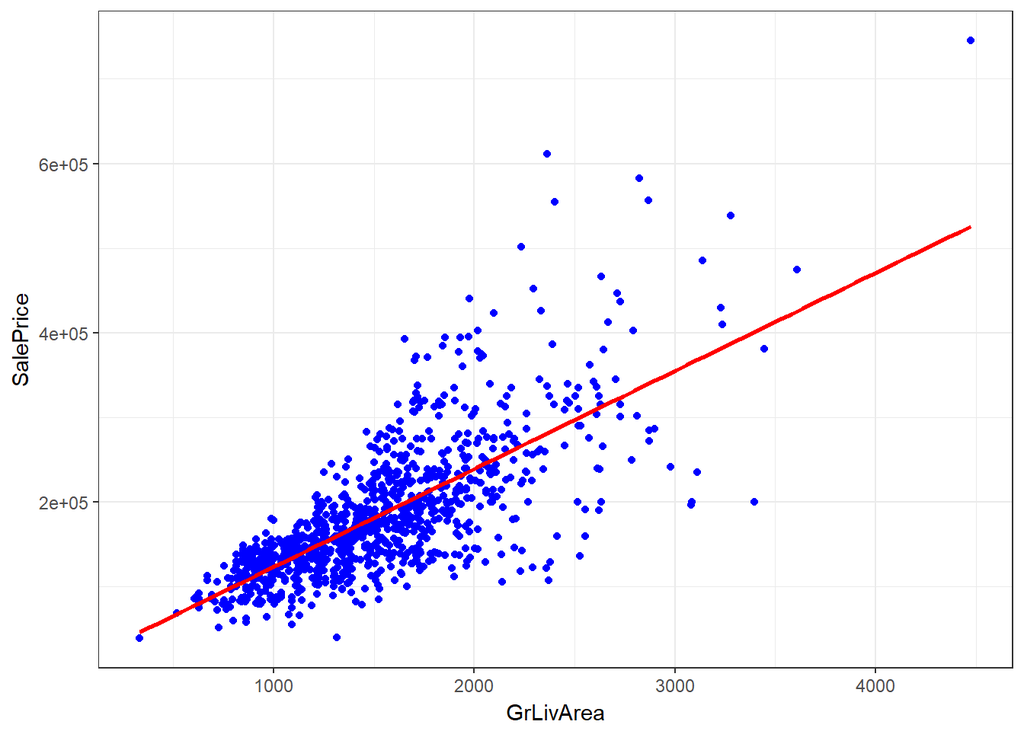

```r
ggplot(train_set, aes(x = GrLivArea, y = SalePrice)) +
  geom_point(color = "blue") +
  geom_smooth(method = "lm", se = FALSE, color = "red") +
  theme_bw()
```

The relationship between SalePrice and GrLivArea is linear. It can be estimated linearly. It is an important feature to estimate as it impacts the SalePrice.

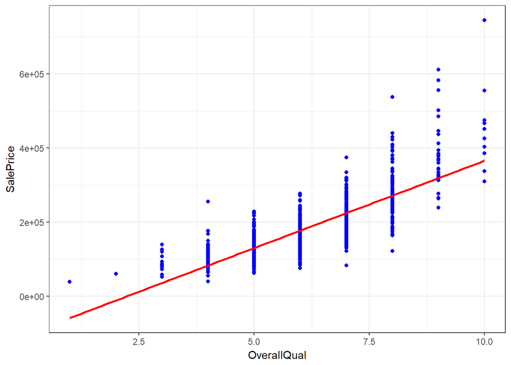

```r
ggplot(train_set, aes(x = OverallQual, y = SalePrice)) +
  geom_point(color = "blue") +
  geom_smooth(method = "lm", se = FALSE, color = "red") +
  theme_bw()
```

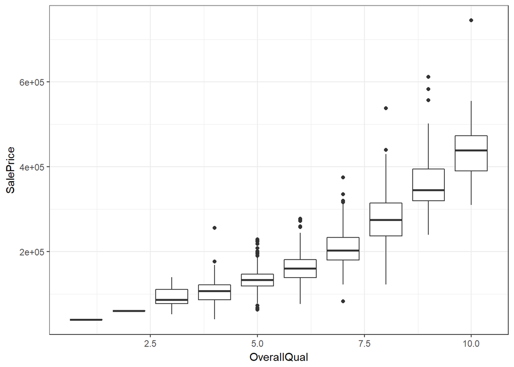

```r
ggplot(train_set, aes(x = OverallQual, y = SalePrice, group=OverallQual)) +
  geom_boxplot() +
  theme_bw()
```

The relationship between SalePrice and OverallQual is linear. It can be estimated linearly. It is an important feature to estimate as it impacts the SalePrice.

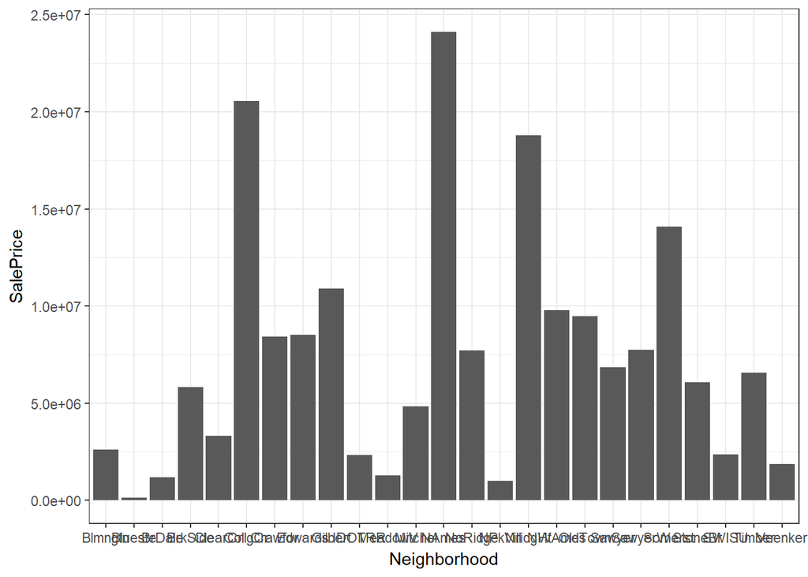

```r
train_set %>%
ggplot() +
  geom_bar(aes(x = Neighborhood, y = SalePrice), stat = 'identity') +
  theme_bw()
```

There is a relationship between SalePrice and Neighborhood. But the Neighborhood is categorical, so no linear relationship with SalePrice. It is an important feature to estimate as it impacts the SalePrice. We will factor it and add to our regression model.

Let’s create the models and see the values.

```r
# Fit a model for GrLivArea
lm_1 <- lm(SalePrice ~ GrLivArea, data = train_set)
mean(train_set$SalePrice)
```

```
## [1] 182176
```

```r
summary(lm_1)
```

```
##
## Call:
## lm(formula = SalePrice ~ GrLivArea, data = train_set)
##
## Residuals:
##     Min      1Q  Median      3Q     Max
## -200772  -29953    -654   22765  330309
##
## Coefficients:
##             Estimate Std. Error t value Pr(>|t|)
## (Intercept) 7518.567   5334.587   1.409    0.159
## GrLivArea    115.833      3.355  34.526   <2e-16 ***
## ---
## Signif. codes:  0 '***' 0.001 '**' 0.01 '*' 0.05 '.' 0.1 ' ' 1
##
## Residual standard error: 54130 on 1020 degrees of freedom
## Multiple R-squared:  0.5389, Adjusted R-squared:  0.5384
## F-statistic:  1192 on 1 and 1020 DF,  p-value: < 2.2e-16
```

```r
tidy(lm_1)
```

```
##          term estimate   std.error statistic       p.value
## 1 (Intercept) 7518.567 5334.586903   1.40940  1.590217e-01
## 2   GrLivArea  115.833    3.354991  34.52558 1.189915e-173
```

```r
glance(lm_1)
```

```
##   r.squared adj.r.squared    sigma statistic       p.value df logLik   AIC
## 1 0.5388821     0.5384301 54125.85  1192.016 1.189915e-173  2 -12588 25182
##        BIC   deviance df.residual
## 1 25196.79 2.9882e+12        1020
```

```r
# Fit a model for OverallQual
lm_2 <- lm(SalePrice ~ OverallQual, data = train_set)
mean(train_set$SalePrice)
```

```
## [1] 182176
```

```r
summary(lm_2)
```

```
##
## Call:
## lm(formula = SalePrice ~ OverallQual, data = train_set)
##
## Residuals:
##     Min      1Q  Median      3Q     Max
## -149666  -29233   -1589   20175  378950
##
## Coefficients:
##             Estimate Std. Error t value Pr(>|t|)
## (Intercept)  -105873       6894  -15.36   <2e-16 ***
## OverallQual    47192       1103   42.80   <2e-16 ***
## ---
## Signif. codes:  0 '***' 0.001 '**' 0.01 '*' 0.05 '.' 0.1 ' ' 1
##
## Residual standard error: 47670 on 1020 degrees of freedom
## Multiple R-squared:  0.6423, Adjusted R-squared:  0.642
## F-statistic:  1832 on 1 and 1020 DF,  p-value: < 2.2e-16
```

```r
tidy(lm_2)
```

```
##          term  estimate std.error statistic       p.value
## 1 (Intercept) -105872.5  6893.466 -15.35839  4.801210e-48
## 2 OverallQual   47192.3  1102.649  42.79902 5.918164e-230
```

```r
glance(lm_2)
```

```
##   r.squared adj.r.squared    sigma statistic       p.value df    logLik
## 1 0.6423257      0.641975 47669.72  1831.756 5.918164e-230  2 -12458.19
##        AIC      BIC     deviance df.residual
## 1 24922.38 24937.17 2.317851e+12        1020
```

```r
# Fit a model for Neighborhood
train_set <- train_set %>% mutate(Neighborhood_fct = factor(Neighborhood, ordered = FALSE))
lm_3 <- lm(SalePrice ~ Neighborhood_fct, data = train_set)
mean(train_set$SalePrice)
```

```
## [1] 182176
```

```r
summary(lm_3)
```

```
##
## Call:
## lm(formula = SalePrice ~ Neighborhood_fct, data = train_set)
##
## Residuals:
##     Min      1Q  Median      3Q     Max
## -164344  -27697   -5142   19353  409437
##
## Coefficients:
##                         Estimate Std. Error t value Pr(>|t|)
## (Intercept)               200309      14880  13.461  < 2e-16 ***
## Neighborhood_fctBlueste   -76309      55677  -1.371 0.170820
## Neighborhood_fctBrDale    -92909      21980  -4.227 2.59e-05 ***
## Neighborhood_fctBrkSide   -76713      16813  -4.563 5.68e-06 ***
## Neighborhood_fctClearCr    19854      20330   0.977 0.329026
## Neighborhood_fctCollgCr    -4492      15774  -0.285 0.775900
## Neighborhood_fctCrawfor     4905      17077   0.287 0.773989
## Neighborhood_fctEdwards   -69405      16300  -4.258 2.26e-05 ***
## Neighborhood_fctGilbert    -9248      16490  -0.561 0.575045
## Neighborhood_fctIDOTRR    -94072      18769  -5.012 6.37e-07 ***
## Neighborhood_fctMeadowV  -103085      21044  -4.899 1.13e-06 ***
## Neighborhood_fctMitchel   -44659      17728  -2.519 0.011920 *
## Neighborhood_fctNAmes     -54161      15455  -3.504 0.000478 ***
## Neighborhood_fctNoRidge   135254      18617   7.265 7.50e-13 ***
## Neighborhood_fctNPkVill   -59059      25152  -2.348 0.019067 *
## Neighborhood_fctNridgHt   118035      16438   7.181 1.36e-12 ***
## Neighborhood_fctNWAmes    -12272      16637  -0.738 0.460904
## Neighborhood_fctOldTown   -72381      16134  -4.486 8.10e-06 ***
## Neighborhood_fctSawyer    -63193      16703  -3.783 0.000164 ***
## Neighborhood_fctSawyerW   -20426      16981  -1.203 0.229323
## Neighborhood_fctSomerst    34566      16413   2.106 0.035457 *
## Neighborhood_fctStoneBr   118544      19311   6.139 1.20e-09 ***
## Neighborhood_fctSWISU     -52975      20033  -2.644 0.008313 **
## Neighborhood_fctTimber     52346      18225   2.872 0.004162 **
## Neighborhood_fctVeenker    63620      25152   2.529 0.011579 *
## ---
## Signif. codes:  0 '***' 0.001 '**' 0.01 '*' 0.05 '.' 0.1 ' ' 1
##
## Residual standard error: 53650 on 997 degrees of freedom
## Multiple R-squared:  0.5571, Adjusted R-squared:  0.5465
## F-statistic: 52.26 on 24 and 997 DF,  p-value: < 2.2e-16
```

```r
tidy(lm_3)
```

```
##                       term    estimate std.error  statistic      p.value
## 1              (Intercept)  200308.462  14880.25 13.4613631 4.487217e-38
## 2  Neighborhood_fctBlueste  -76308.462  55676.80 -1.3705612 1.708203e-01
## 3   Neighborhood_fctBrDale  -92908.462  21979.59 -4.2270339 2.585277e-05
## 4  Neighborhood_fctBrkSide  -76713.249  16812.68 -4.5628209 5.675519e-06
## 5  Neighborhood_fctClearCr   19853.672  20330.29  0.9765561 3.290259e-01
## 6  Neighborhood_fctCollgCr   -4491.700  15774.54 -0.2847437 7.758997e-01
## 7  Neighborhood_fctCrawfor    4905.221  17077.14  0.2872390 7.739890e-01
## 8  Neighborhood_fctEdwards  -69405.077  16300.50 -4.2578500 2.259005e-05
## 9  Neighborhood_fctGilbert   -9247.988  16490.05 -0.5608225 5.750446e-01
## 10  Neighborhood_fctIDOTRR  -94072.098  18768.65 -5.0121942 6.365074e-07
## 11 Neighborhood_fctMeadowV -103085.385  21043.85 -4.8985984 1.125722e-06
## 12 Neighborhood_fctMitchel  -44658.462  17727.84 -2.5191151 1.192047e-02
## 13   Neighborhood_fctNAmes  -54161.231  15455.33 -3.5043723 4.780249e-04
## 14 Neighborhood_fctNoRidge  135254.147  18616.48  7.2652908 7.499696e-13
## 15 Neighborhood_fctNPkVill  -59058.462  25152.21 -2.3480422 1.906702e-02
## 16 Neighborhood_fctNridgHt  118035.386  16438.06  7.1806164 1.355530e-12
## 17  Neighborhood_fctNWAmes  -12271.923  16636.63 -0.7376449 4.609038e-01
## 18 Neighborhood_fctOldTown  -72380.651  16134.44 -4.4860949 8.097746e-06
## 19  Neighborhood_fctSawyer  -63192.622  16703.04 -3.7833005 1.639801e-04
## 20 Neighborhood_fctSawyerW  -20425.787  16981.27 -1.2028425 2.293228e-01
## 21 Neighborhood_fctSomerst   34565.772  16413.31  2.1059604 3.545731e-02
## 22 Neighborhood_fctStoneBr  118543.907  19311.16  6.1386206 1.199918e-09
## 23   Neighborhood_fctSWISU  -52975.087  20033.15 -2.6443711 8.312879e-03
## 24  Neighborhood_fctTimber   52345.885  18224.51  2.8722792 4.161598e-03
## 25 Neighborhood_fctVeenker   63620.110  25152.21  2.5294039 1.157881e-02
```

```r
glance(lm_3)
```

```
##   r.squared adj.r.squared    sigma statistic       p.value df    logLik
## 1 0.5571452     0.5464847 53651.51  52.26259 1.011167e-157 25 -12567.35
##       AIC      BIC     deviance df.residual
## 1 25186.7 25314.87 2.869849e+12         997
```

```r
# Fit a model with all three variables
lm_4 <- lm(SalePrice ~ GrLivArea + OverallQual + Neighborhood_fct, data = train_set)
mean(train_set$SalePrice)
```

```
## [1] 182176
```

```r
summary(lm_4)
```

```
##
## Call:
## lm(formula = SalePrice ~ GrLivArea + OverallQual + Neighborhood_fct,
##     data = train_set)
##
## Residuals:
##     Min      1Q  Median      3Q     Max
## -118777  -17495     -57   16149  249166
##
## Coefficients:
##                           Estimate Std. Error t value Pr(>|t|)
## (Intercept)             -45017.875  12933.342  -3.481 0.000522 ***
## GrLivArea                   62.777      3.006  20.884  < 2e-16 ***
## OverallQual              21692.232   1353.714  16.024  < 2e-16 ***
## Neighborhood_fctBlueste -38288.881  36531.907  -1.048 0.294850
## Neighborhood_fctBrDale  -43314.054  14524.694  -2.982 0.002933 **
## Neighborhood_fctBrkSide -14064.371  11318.850  -1.243 0.214322
## Neighborhood_fctClearCr  27839.007  13561.347   2.053 0.040351 *
## Neighborhood_fctCollgCr   4297.674  10372.304   0.414 0.678713
## Neighborhood_fctCrawfor   7423.056  11371.512   0.653 0.514051
## Neighborhood_fctEdwards -15284.115  10994.287  -1.390 0.164783
## Neighborhood_fctGilbert  -8357.559  10894.173  -0.767 0.443169
## Neighborhood_fctIDOTRR  -32689.431  12603.713  -2.594 0.009636 **
## Neighborhood_fctMeadowV -14446.065  14190.149  -1.018 0.308909
## Neighborhood_fctMitchel   1922.315  11788.608   0.163 0.870500
## Neighborhood_fctNAmes    -7719.679  10375.956  -0.744 0.457054
## Neighborhood_fctNoRidge  47685.168  12567.433   3.794 0.000157 ***
## Neighborhood_fctNPkVill -20240.711  16548.665  -1.223 0.221581
## Neighborhood_fctNridgHt  63872.808  10880.457   5.870 5.92e-09 ***
## Neighborhood_fctNWAmes  -12279.333  11047.503  -1.112 0.266620
## Neighborhood_fctOldTown -36107.076  10849.171  -3.328 0.000906 ***
## Neighborhood_fctSawyer   -4121.925  11252.370  -0.366 0.714207
## Neighborhood_fctSawyerW  -5391.971  11230.758  -0.480 0.631257
## Neighborhood_fctSomerst  18700.967  10772.213   1.736 0.082867 .
## Neighborhood_fctStoneBr  65712.459  12745.313   5.156 3.05e-07 ***
## Neighborhood_fctSWISU   -45451.867  13564.793  -3.351 0.000836 ***
## Neighborhood_fctTimber   27925.086  11985.326   2.330 0.020009 *
## Neighborhood_fctVeenker  54913.128  16521.075   3.324 0.000920 ***
## ---
## Signif. codes:  0 '***' 0.001 '**' 0.01 '*' 0.05 '.' 0.1 ' ' 1
##
## Residual standard error: 35180 on 995 degrees of freedom
## Multiple R-squared:   0.81,  Adjusted R-squared:  0.805
## F-statistic: 163.1 on 26 and 995 DF,  p-value: < 2.2e-16
```

```r
tidy(lm_4)
```

```
##                       term     estimate    std.error  statistic
## 1              (Intercept) -45017.87483 12933.341808 -3.4807612
## 2                GrLivArea     62.77735     3.006033 20.8837885
## 3              OverallQual  21692.23178  1353.714104 16.0242342
## 4  Neighborhood_fctBlueste -38288.88063 36531.907177 -1.0480942
## 5   Neighborhood_fctBrDale -43314.05372 14524.693991 -2.9820975
## 6  Neighborhood_fctBrkSide -14064.37052 11318.850018 -1.2425618
## 7  Neighborhood_fctClearCr  27839.00662 13561.346871  2.0528202
## 8  Neighborhood_fctCollgCr   4297.67432 10372.304467  0.4143413
## 9  Neighborhood_fctCrawfor   7423.05573 11371.511784  0.6527765
## 10 Neighborhood_fctEdwards -15284.11495 10994.287187 -1.3901870
## 11 Neighborhood_fctGilbert  -8357.55930 10894.173472 -0.7671586
## 12  Neighborhood_fctIDOTRR -32689.43085 12603.712743 -2.5936350
## 13 Neighborhood_fctMeadowV -14446.06504 14190.148622 -1.0180348
## 14 Neighborhood_fctMitchel   1922.31487 11788.608170  0.1630655
```

[output cut: 41 more lines]

```r
glance(lm_4)
```

```
##   r.squared adj.r.squared   sigma statistic p.value df    logLik      AIC
## 1 0.8099927     0.8050277 35178.1  163.1401       0 27 -12134.95 24325.91
##        BIC     deviance df.residual
## 1 24463.93 1.231311e+12         995
```

**How would you interpret the coefficients on GrLivArea and OverallQual?**

The coefficient for the GrLivArea predictor is 115.833. This means that for every increase by one square foot the house price increases by 115.833 dollars.

The coefficient for the OverallQual predictor is 47192. This means that for every increase by one point for the overall quality, the house price increases by 47192 dollars.

**Answer**

**How would you interpret the coefficient on NeighborhoodBrkSide?**

**Are the features significant?**

**Are the features practically significant?**

Practically, all three can be significant. For Neighborhood, we can classify the data for each Neighborhood and predict.

**Answer**

**Is the model a good fit (to the training set)?**

**Answer**

The adjusted R2 for the model is 0.8050277. This means that the model explains 80.5% of variability of the response data around its mean. I would say it is not a best model. We have to add more variables to get higher accuracy.

## Evaluate the model

**Exercise 5**

**Evaluate the model on test_set using the root mean squared error (RMSE). Use the predict function to get the model predictions for the testing set.**

**Hint: use the sqrt() and mean() functions:**

```r
test_predictions <- predict(NAME_OF_YOUR_MODEL_HERE, newdata = test_set)
rmse <- sqrt(mean((___ - ___)^2))
```

**Answer**

Let’s predict on the test data and evaluate the model.

```r
test_set <- test_set %>% mutate(Neighborhood_fct = factor(Neighborhood, ordered = FALSE))
test_predictions <- predict(lm_4, newdata = test_set)
rmse <- sqrt(mean((test_set$SalePrice - test_predictions)^2))
rmse
```

```
## [1] 41915.27
```

From the above RMSE value, we cal conclude, may be it is not a best model to predict the sales price.

# Linear Model : downside

**Exercise 7**

**One downside of the linear model is that it is sensitive to unusual values because the distance incorporates a squared term. Fit a linear model to the simulated data below, and visualise the results. Rerun a few times to generate different simulated datasets. What do you notice about the model?**

```r
sim1a <- tibble(
x = rep(1:10, each = 3),
y = x * 1.5 + 6 + rt(length(x), df = 2)
)
```

**Answer**

Lets create a model and run on the simulated data and visualize it.

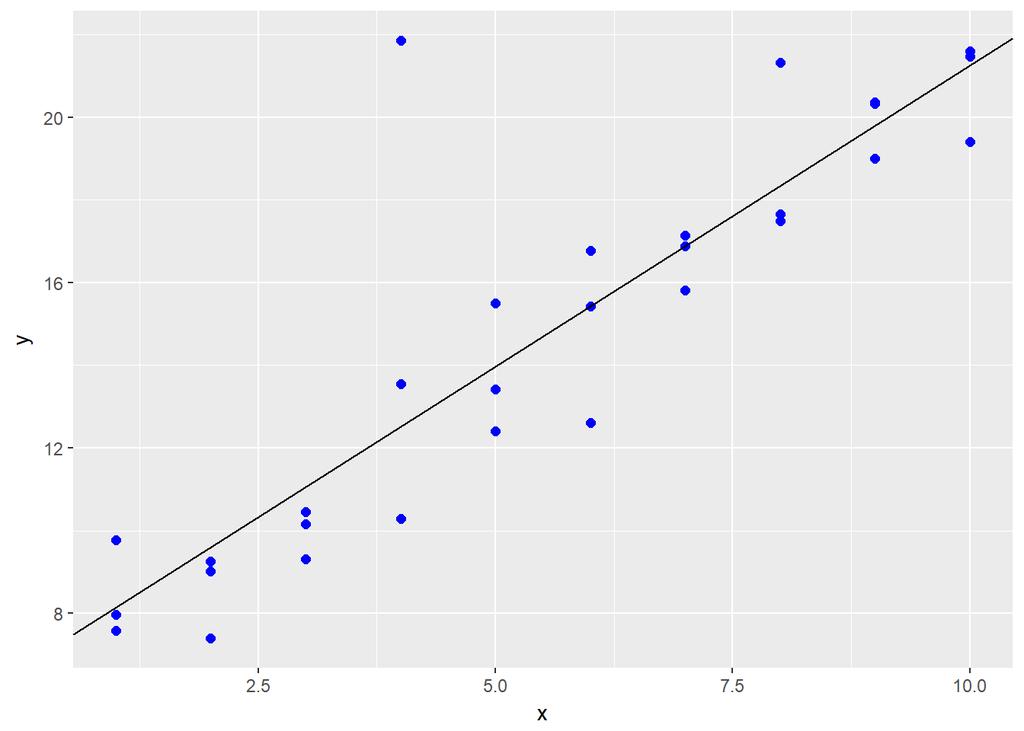

```r
sim1a <- tibble(
x = rep(1:10, each = 3),
y = x * 1.5 + 6 + rt(length(x), df = 2)
)

mod_5 <- lm(y~x, data = sim1a)
ggplot(sim1a,aes(x,y))+
  geom_point(size = 2, color = "blue")+
  geom_abline(intercept = mod_5$coefficients[1],slope = mod_5$coefficients[2])
```

Now, let’s run for few times.

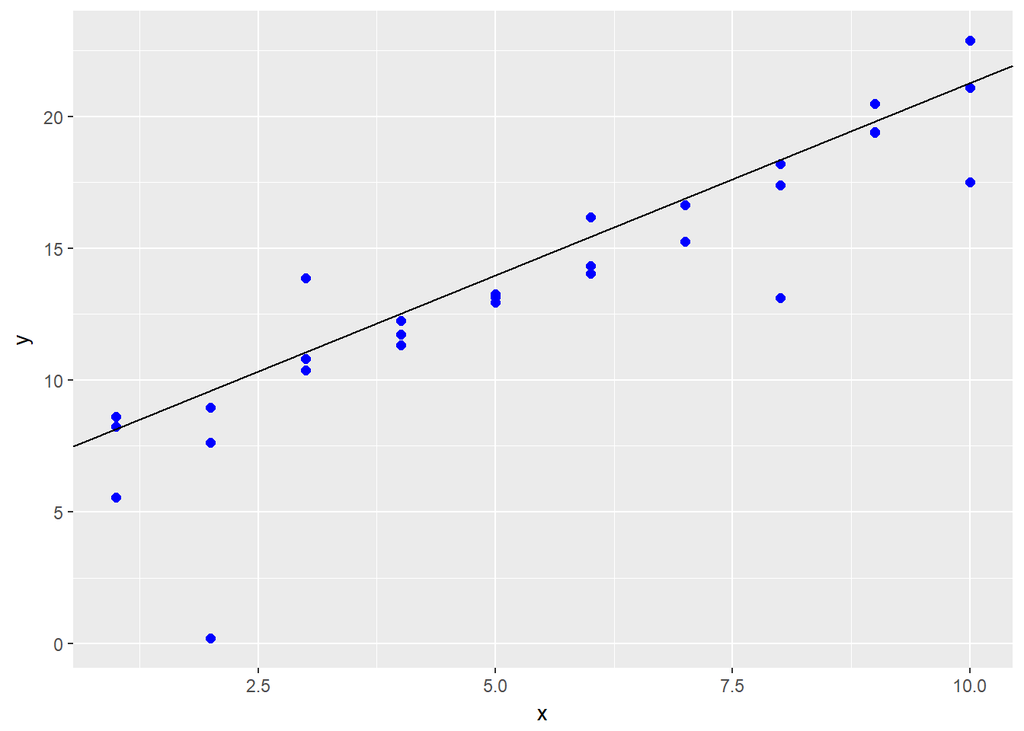

```r
sim2a <- tibble(
x = rep(1:10, each = 3),
y = x * 1.5 + 6 + rt(length(x), df = 2)
)

mod_5 <- lm(y~x, data = sim1a)
ggplot(sim2a,aes(x,y))+
  geom_point(size = 2, color = "blue")+
  geom_abline(intercept = mod_5$coefficients[1],slope = mod_5$coefficients[2])
```

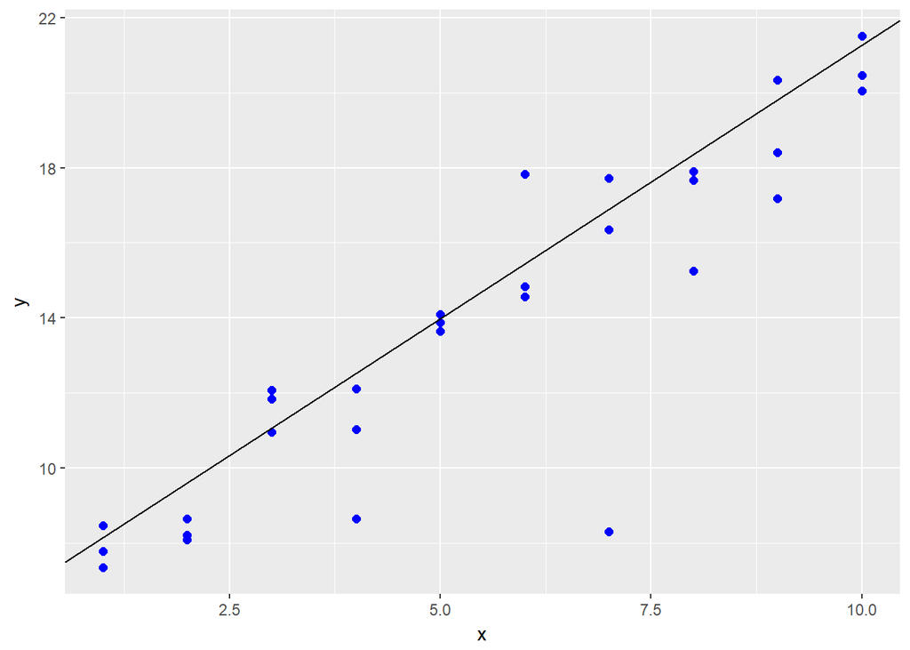

```r
sim3a <- tibble(
x = rep(1:10, each = 3),
y = x * 1.5 + 6 + rt(length(x), df = 2)
)

mod_5 <- lm(y~x, data = sim1a)
ggplot(sim3a,aes(x,y))+
  geom_point(size = 2, color = "blue")+
  geom_abline(intercept = mod_5$coefficients[1],slope = mod_5$coefficients[2])
```

———————————————————————————————————

**End of Homework 7**